# Surds

## Notes and examples

### Rational and irrational numbers

An irrational number is a number which cannot be expressed as one whole number divided by another whole number. Irrational numbers can’t be written as fractions.

In this section you will learn to manipulate and simplify expressions involving surds. This is an important skill in many areas of mathematics. For example, suppose you have a triangular paving slab like this:

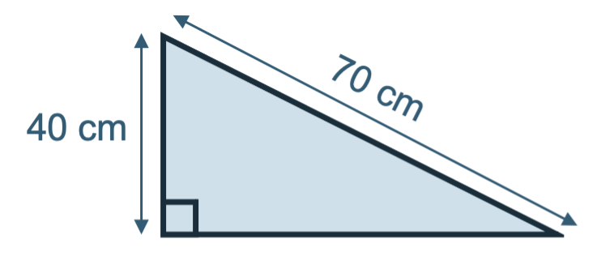

right angled triangle with hypotenuse 70cm and a shorter side of 40cm

### Writing a square root in terms of a simpler square root

**Example 1**

Write these numbers in terms of the simplest possible square roots.

1. $\sqrt{12}$
2. $\sqrt{72}$
3. $\sqrt{150}$

### Adding and subtracting surds

Adding and subtracting surds is rather like adding or subtracting algebraic expressions, in that you have to collect “like terms”. You should collect together any rational numbers, and collect together any terms involving roots of the same number. You cannot collect together terms involving roots of different numbers, such as $\sqrt{2}$ and $\sqrt{3}$.

**Example 2**

Simplify

1. $(2+\sqrt{2})+(3-2\sqrt{2})$
2. $(4-\sqrt{3})-(1-2\sqrt{2}+3\sqrt{3})$
3. $\sqrt32-\sqrt{18}$

*Solution*

1. $\begin{aligned} (2+\sqrt{2})+(3-2\sqrt{2}) &= 2+3+\sqrt{2}-2\sqrt{2} \\ &=5-\sqrt{2} \end{aligned}$
2. $\begin{aligned} (4-\sqrt{3})-(1-2\sqrt{2}+3\sqrt{3}) &= 4-\sqrt{3}-1+2\sqrt{2}-3\sqrt{3} \\ &=4-1-\sqrt{3}-3\sqrt{3}+2\sqrt{2} \\ &=3-4\sqrt{3}+2\sqrt{2} \end{aligned}$
3. $\begin{aligned} &\textit{At first sight this looks like it cannot be simplified. However, both surds can be written in terms of simpler surds (as in Example 1).} \\ &\sqrt{32}=\sqrt{16}\times\sqrt{2}=4\sqrt{2} \\ &\sqrt{18}=\sqrt{9}\times\sqrt{2}=3\sqrt{2} \\ &\sqrt{32}-\sqrt{18}=4\sqrt{2}-3\sqrt{2}=\sqrt{2} \\ \end{aligned}$

### Multiplying surds

Multiplying two or more square roots is quite simple – you just multiply the numbers. You may then be able to write the result as a simpler surd.

**Example 3**

Simplify

1. $\sqrt 2 \times \sqrt 6$
2. $2\sqrt {15} \times \sqrt 6 \times 3\sqrt {10}$

*Solution*

1. $\begin{array}{l} \sqrt 2 \times \sqrt 6 &= \sqrt {12} \\ &= \sqrt 4 \times \sqrt 3 \\ &= 2\sqrt 3 \end{array}$

*The approach used in part (a) works well for small numbers, but for part (b) you would get the square root of a large number to simplify. An easier way for this example is to split each surd into simpler ones and then look for any pairs.*

2. $\begin{array}{l} 2\sqrt {15} \times \sqrt 6 \times 3\sqrt {10} &= (2 \times \sqrt 3 \times \sqrt 5 ) \times (\sqrt 2 \times \sqrt 3 ) \times (3 \times \sqrt 5 \times \sqrt 2 )\\ &= 2 \times 3 \times \sqrt 3 \times \sqrt 3 \times \sqrt 5 \times \sqrt 5 \times \sqrt 2 \times \sqrt 2 \\ &= 6 \times 3 \times 5 \times 2\\ &= 180 \end{array}$

The next example deals with multiplying expressions involving a mixture of rational numbers and roots. You have to use brackets for this, and it is very similar to multiplying out two brackets in algebra – each term in the first bracket needs to be multiplied by each term in the second bracket. You can use FOIL (First, Outer, Inner, Last) if it helps you.

**Example 4**

Multiply out and simplify

1. $(2 + \sqrt 3 )(1 - 2\sqrt 3 )$
2. ${(3 - \sqrt 2 )^2}$
3. $(\sqrt 5 - 2)(\sqrt 5 + 2)$

*Solution*

1. $\begin{align} (2 + \sqrt 3 )(1 - 2\sqrt 3 ) &= 2 - 4\sqrt 3 + \sqrt 3 - 2\sqrt 3 \times \sqrt 3 \\ &= 2 - 3\sqrt 3 - 6\\ &= - 4 - 3\sqrt 3 \end{align}$
2. $\begin{align} {(3 - \sqrt 2 )^2} &= (3 - \sqrt 2 )(3 - \sqrt 2 )\\ &= 9 - 3\sqrt 2 - 3\sqrt 2 + \sqrt 2 \times \sqrt 2 \\ &= 9 - 6\sqrt 2 + 2\\ &= 11 - 6\sqrt 2 \end{align}$
3. $\begin{align} (\sqrt 5 - 2)(\sqrt 5 + 2) &= \sqrt 5 \times \sqrt 5 + 2\sqrt 5 - 2\sqrt 5 - 2 \times 2\\ &= 5 - 4\\ &= 1 \end{align}$

Part (c) of Example 4 illustrates a very important and useful idea. Multiplying out any expression of the form $(a+b)(a-b)$ gives the result $a^{2}-b^{2}$. The “outer” and “inner” products,$-ab$ and $ab$, cancel each other out. When either or both of *a* and *b* are surds, the result $a^{2}-b^{2}$ is a rational number.

### Rationalising the denominator

Surds in the denominator of a fraction can be a real nuisance! However, you can get rid of them from the denominator by a process called rationalising the denominator, which uses the idea above. If the denominator of a fraction is *a* + *b*, where either or both of *a* and *b* are surds, then you can multiply both top and bottom of the fraction by *a* – *b*. The denominator is then $(a+b)(a-b)$, which expands to give a rational number. Since you multiply the top and bottom of the fraction by the same amount, its value is unchanged. The numerator still involves surds, but this is not quite so difficult to work with.

This technique is shown in Example 5.

**Example 5**

Simplify the following by rationalising the denominator.

1. $\frac{1}{{\sqrt 3 }}$
2. $\frac{1}{{\sqrt 2 + 1}}$
3. $\frac{{2 + \sqrt 3 }}{{1 - \sqrt 3 }}$

*Solution*

*Remember if the denominator of a fraction is a surd then the fraction is not in its simplest form.*

$\begin{align} \textbf{a.} \hspace{1em} \frac{1}{{\sqrt 3 }} &= \frac{1}{{\sqrt 3 }} \times \frac{{\sqrt 3 }}{{\sqrt 3 }}\\ &= \frac{{\sqrt 3 }}{3} \end{align}$

$\begin{align} \textbf{b.} \hspace{1em} \frac{1}{{\sqrt 2 + 1}} &= \frac{1}{{\sqrt 2 + 1}} \times \frac{{\sqrt 2 - 1}}{{\sqrt 2 - 1}}\\ &= \frac{{\sqrt 2 - 1}}{{(\sqrt 2 + 1)(\sqrt 2 - 1)}}\\ &= \frac{{\sqrt 2 - 1}}{{2 - 1}}\\ &= \sqrt 2 - 1 \end{align}$

$\begin{align} \textbf{c.} \hspace{1em} \frac{{2 + \sqrt 3 }}{{1 - \sqrt 3 }} &= \frac{{2 + \sqrt 3 }}{{1 - \sqrt 3 }} \times \frac{{1 + \sqrt 3 }}{{1 + \sqrt 3 }}\\ &= \frac{{(2 + \sqrt 3 )(1 + \sqrt 3 )}}{{(1 - \sqrt 3 )(1 + \sqrt 3 )}}\\ &= \frac{{2 + 2\sqrt 3 + \sqrt 3 + 3}}{{1 - 3}}\\ &= - {\textstyle{1 \over 2}}(5 + 3\sqrt 3 ) \end{align}$